# CS18_Experiment2_analysis

Jeanne

December 3, 2018

# Experiment 2: Learning task

Same as in Experiment 1:  
In this task, participants saw two pictures on the screen and heard one word. Their task was to indicate which picture the word matched with using a button pad. THey would get feedback on their answer (the accuracy picture staid on the screen while the inaccuracy one disappeared, sometimes replaced by the word’s spelling).

```r
##reading the learning task data
exp2_training <- read.csv("Experiment2_training_masterFile.csv", header=T)

##excluding subjects who performed poorly (on training and/or on the picture matching task. Bases for exclusion described in paper)

exp2_training.sub<-exp2_training[!exp2_training$ID %in% c("CN1","CN2","CN3","CN6","CN12","CN13","CN18","CN33",
                                                     "VN3","VN9","VN15","VN24",
                                                     "CV1","CV2","CV3","CV23"),]

##data



#length(exp2_training.sub$RT) # 57600

##eliminating trials that were too fast (i.e. <250 ms)
exp2_training.sub250 <- exp2_training.sub[exp2_training.sub$RT>250,]

#length(exp2_training.sub250$RT) #57030
## --> eliminating trials faster than 250ms resulted in excuding about 1% of the data
```

#### Means:

```r
exp2_training.mean <- aggregate(accuracy ~ block+repetition+session, exp2_training.sub250, FUN="mean")
exp2_training.mean
```

```
##    block repetition   session accuracy
## 1     B1          1 session 1     0.65
## 2     B1          2 session 1     0.68
## 3     B1          3 session 1     0.76
## 4     B1          4 session 1     0.80
## 5     B1          5 session 1     0.85
## 6     B1          6 session 1     0.87
## 7     B1          7 session 1     0.88
## 8     B2          8 session 1     0.89
## 9     B2          9 session 1     0.88
## 10    B2         10 session 1     0.90
## 11    B2         11 session 1     0.90
## 12    B2         12 session 1     0.92
## 13    B2         13 session 1     0.92
## 14    B2         14 session 1     0.92
```

[output cut: 16 more lines]

#### Plot:

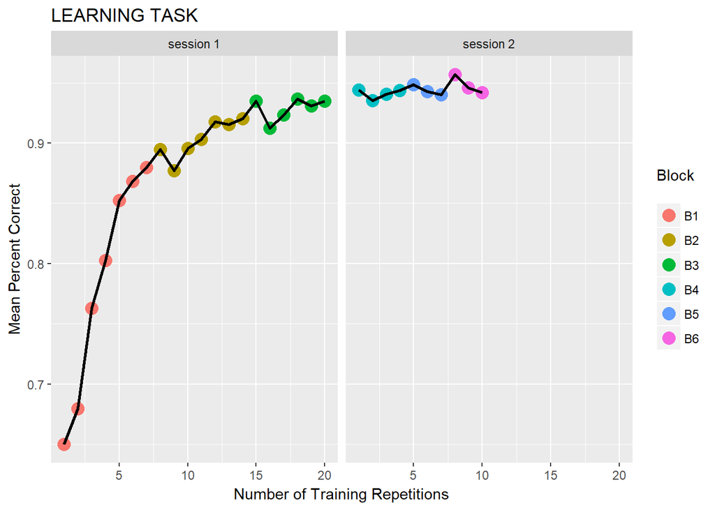

By the end of the learning task, subjects were at ceiling.

# Experiment 2: Picture Matching task

Reading the data frame.

```r
##reading Picture matching task data
exp2_data<-read.csv("Experiment2_testing_masterFile.csv", header=T)
str(exp2_data)
```

```
## 'data.frame':    29184 obs. of  14 variables:
##  $ ID               : Factor w/ 76 levels "CN1","CN11","CN12",..: 1 1 1 1 1 1 1 1 1 1 ...
##  $ group            : Factor w/ 3 levels "Canonical_None",..: 1 1 1 1 1 1 1 1 1 1 ...
##  $ item             : Factor w/ 128 levels "abron","apron",..: 65 81 8 16 55 24 60 90 23 87 ...
##  $ item.number      : int  69 42 4 110 17 98 66 89 71 39 ...
##  $ item.duration    : int  NA 637 NA 568 NA 478 NA NA NA 630 ...
##  $ pronunciation    : Factor w/ 4 levels "Familiar words",..: 4 2 1 3 1 3 4 4 4 2 ...
##  $ button.pressed   : int  1 1 1 1 1 1 1 1 1 1 ...
##  $ accuracy         : int  0 0 1 1 1 1 0 0 0 0 ...
##  $ RT               : int  2698 777 956 622 696 514 841 1102 804 714 ...
##  $ trial            : int  0 1 2 3 4 5 6 7 8 9 ...
##  $ session          : Factor w/ 3 levels "session 1","session 2",..: 1 1 1 1 1 1 1 1 1 1 ...
##  $ spelling.learned : Factor w/ 4 levels "","canonical",..: 1 2 1 3 1 3 1 1 1 2 ...
##  $ reduction        : Factor w/ 3 levels "","flap","nasal": 1 3 1 3 1 2 1 1 1 2 ...
##  $ spelling.recalled: int  NA 1 NA NA NA NA NA NA NA 1 ...
```

How many subjects in each group?

```
##               group Subjects
## 1    Canonical_None       28
## 2 Canonical_Reduced       24
## 3      Reduced_None       24
```

Our plan was to collect data from 20 subjects per groups. Due to some subjects’ poor performance on the controls trials, we had to run additional subjects in all the groups.

Our bases for exclusion were:

```
1) performance below two standard deviations from the group mean during the last block of the learning phase and/or
2) performance below two standard deviations from the group mean on the familiar words trials during the picture matching task.
```

In addition, one subject was excluded because of experimenter error.

Excluded subjects were:

```
In the Canonical_None group: CN1, CN2, CN3, CN6, CN12, CN13, CN18, CN33
In the Reduced_None group: VN3, VN9, VN15, VN24
In the Canonical_Reduced group: CV1, CV2, CV3, CV23
```

```
##               group Subjects
## 1    Canonical_None       20
## 2 Canonical_Reduced       20
## 3      Reduced_None       20
```

Additionally, we excluded data from trials where subjects answered in less than 250ms (<< 1% of the trials).

```
##    Min. 1st Qu.  Median    Mean 3rd Qu.    Max.
##     254     678     813     885     988    4745
```

## ACCURACY ANALYSES: CONTROL TRIALS OVER ALL THREE PICTURE MATCHING TASKS OF EXPERIMENT 2

During the Picture Matching task, subjects saw a picture on the computer screen and heard a word through the headphones. Their task was to indicate whether the picture and the word matched by pressing ‘yes’ or ‘no’ on a button pad.

There were 4 types of trials in a sense:  
1)control trial type 1: a newly learned object is presented with its newly learned pronunciation (i.e. the reduced pronunciation). For example the picture of a “bytto” with spoken word “byddo”  
2)control trial type 2: a familiar object is presented with its accuracy English pronunciation. For example the picture of a basketball with spoken word “basketball”  
3)control trial type 3: a familiar object is presented with a nonword. For example the picture of basketball with spoken word “bashketball”  
4)critical trial: a newly learned object is presented with its canonical pronunciation (heard for the 1st time). FOr example the picture of a “bytto” with word “bytto”

Experiment 2 had three separate Picture Matching tasks: one in session 1, a replication of Experiment 1; and two in session two (which occured about 48h after session 1) - one to test consolidation and one to see the effect of additional training.

Useful subsets for analysis:

```r
## subset of canonical pronunciation
exp2_canonical <- exp2_data.sub250[exp2_data.sub250$pronunciation == "New words, canonical pronunciation",]

##subset of variant pronunciationo
exp2_variant <-exp2_data.sub250[exp2_data.sub250$pronunciation == "New words, trained pronunciation",]

##subset of familiar words
exp2_familiar <-exp2_data.sub250[exp2_data.sub250$pronunciation == "Familiar words",]

##subset of mispronounced words
exp2_nonwords <- exp2_data.sub250[exp2_data.sub250$pronunciation == "Nonwords",]
```

Data frame of the control trials:

```r
exp2_controlTrials <- rbind(exp2_familiar, exp2_nonwords, exp2_variant)
```

### Control trials: % accuracy across groups and sessions (1, 2, and 3)

#### Means:

```
##                       pronunciation             group   session accuracy
## 1                    Familiar words    Canonical_None session 1     0.97
## 2  New words, trained pronunciation    Canonical_None session 1     0.93
## 3                          Nonwords    Canonical_None session 1     0.88
## 4                    Familiar words Canonical_Reduced session 1     0.97
## 5  New words, trained pronunciation Canonical_Reduced session 1     0.95
## 6                          Nonwords Canonical_Reduced session 1     0.85
## 7                    Familiar words      Reduced_None session 1     0.98
## 8  New words, trained pronunciation      Reduced_None session 1     0.95
## 9                          Nonwords      Reduced_None session 1     0.89
## 10                   Familiar words    Canonical_None session 2     0.97
## 11 New words, trained pronunciation    Canonical_None session 2     0.88
## 12                         Nonwords    Canonical_None session 2     0.89
## 13                   Familiar words Canonical_Reduced session 2     0.97
## 14 New words, trained pronunciation Canonical_Reduced session 2     0.91
## 15                         Nonwords Canonical_Reduced session 2     0.90
## 16                   Familiar words      Reduced_None session 2     0.97
## 17 New words, trained pronunciation      Reduced_None session 2     0.94
## 18                         Nonwords      Reduced_None session 2     0.93
## 19                   Familiar words    Canonical_None session 3     0.96
## 20 New words, trained pronunciation    Canonical_None session 3     0.93
## 21                         Nonwords    Canonical_None session 3     0.92
## 22                   Familiar words Canonical_Reduced session 3     0.97
## 23 New words, trained pronunciation Canonical_Reduced session 3     0.96
## 24                         Nonwords Canonical_Reduced session 3     0.93
## 25                   Familiar words      Reduced_None session 3     0.97
## 26 New words, trained pronunciation      Reduced_None session 3     0.98
## 27                         Nonwords      Reduced_None session 3     0.93
```

We can also look at whether spelling.learned learned seemed to impact accuracy for the “newly learned words” control trials:

```r
##looking specifically at newly learned words and if orthography had an impact on these
newlyL_means<-aggregate(accuracy ~ pronunciation+group+spelling.learned, exp2_variant, FUN="mean")
newlyL_means
```

```
##                      pronunciation             group spelling.learned
## 1 New words, trained pronunciation    Canonical_None        canonical
## 2 New words, trained pronunciation Canonical_Reduced        canonical
## 3 New words, trained pronunciation    Canonical_None             none
## 4 New words, trained pronunciation      Reduced_None             none
## 5 New words, trained pronunciation Canonical_Reduced          reduced
## 6 New words, trained pronunciation      Reduced_None          reduced
##   accuracy
## 1     0.92
## 2     0.94
## 3     0.91
## 4     0.96
## 5     0.94
## 6     0.95
```

#### Plot:

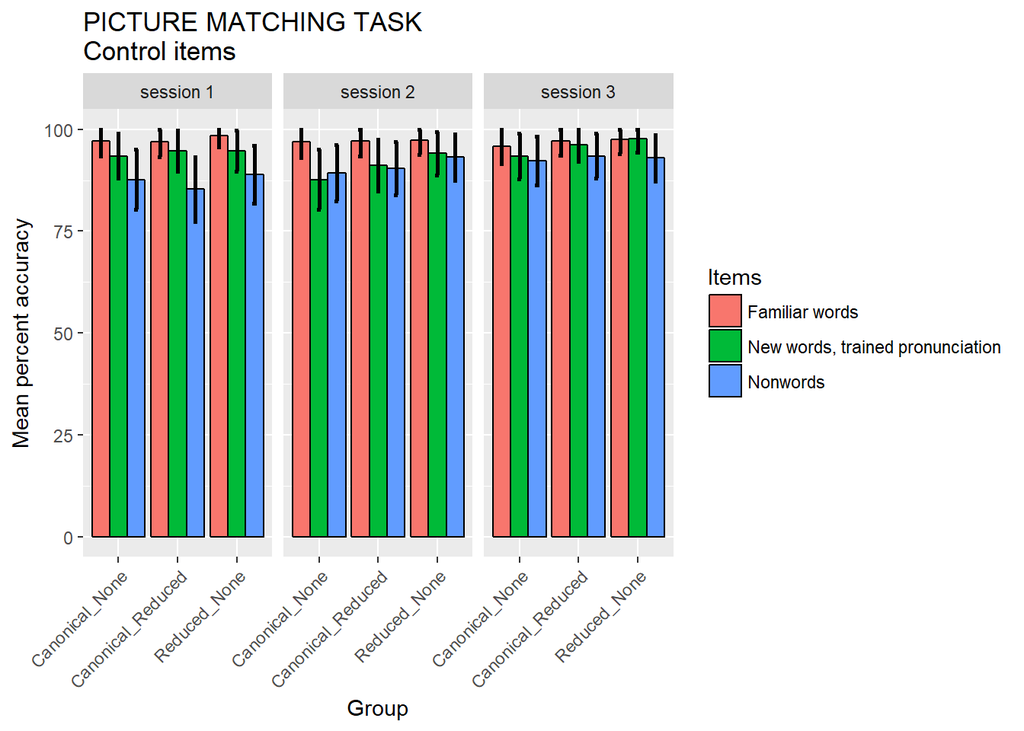

```r
##Calculating standard deviation and standard error to the mean:
control_sd <- aggregate(accuracy~pronunciation+group+session, exp2_controlTrials, FUN="sd")
control_sd$sem<- control_sd$accuracy/sqrt(20) #there are 20 subjects in each group
control_means$sd<-control_sd$accuracy
control_means$sem<-control_sd$sem


##multiply by 100 to get on a more readable % scale
control_means$accuracy<-control_means$accuracy*100
control_means$sd<-control_means$sd*100
control_means$sem<-control_means$sem*100

##if mean + sem>100, make it 100:
control_means$ymin <- control_means$accuracy - control_means$sem
control_means$ymax <- control_means$accuracy + control_means$sem
control_means$ymax[control_means$ymax > 100]<-100

##Code for the plot:

control.plot<-ggplot(control_means, aes(x=group, y=accuracy))+
  geom_bar(stat="identity", position="dodge", aes(fill=pronunciation), color="black")+
  geom_errorbar(aes(ymin=ymin, ymax=ymax, shape=pronunciation), width=.2,size=1, position=position_dodge(.9))+
  theme(axis.text.x=element_text(angle=45,hjust = 1))+
  ylab("Mean percent accuracy")+
  xlab("Group")+
  labs(title= "PICTURE MATCHING TASK\nControl items ",fill="Items")+
  facet_wrap(~session)
control.plot
```

Again, the results on control trials were consistent with our intuitions: high accuracy on all of them, across all three tests. Nonwords trials appeared a little harder than the others, but the stimuli was built such that the mispronunciation would be subtle (only one phoneme differed from the original word, e.g. “abron” for “apron”) and required the subjects’ full attention.

## ACCURACY ANALYSES: EXPERIMENT 2, SESSION 1 - A REPLICATION OF EXPERIMENT 1

Data frame:

```r
##critical trial, session 1 only:
exp2_session1_canonical<-exp2_canonical[exp2_canonical$session == "session 1",]
#summary(exp2_session1_canonical)
```

### Overall effect of orthography in experiment 2, session 1?

Mean accuracy for the critical items for each spelling learned

#### Means:

```r
main_spelling.learned<-aggregate(accuracy~spelling.learned, exp2_session1_canonical, FUN="mean")
main_spelling.learned
```

```
##   spelling.learned accuracy
## 1        canonical     0.43
## 2             none     0.62
## 3          reduced     0.67
```

#### Plot:

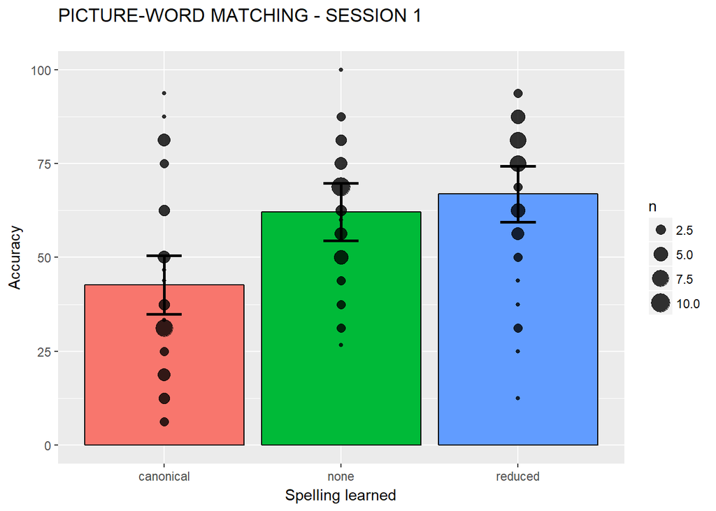

#### Analysis for the main effect of Spelling (Session 1)

Model with spelling.learned as a fixed factor

```r
##model with spelling

spell.mod3<-glmer(accuracy~spelling.learned+(1|ID)+(1|item), data=exp2_session1_canonical, family="binomial")
summary(spell.mod3)
```

```
## Generalized linear mixed model fit by maximum likelihood (Laplace
##   Approximation) [glmerMod]
##  Family: binomial  ( logit )
## Formula: accuracy ~ spelling.learned + (1 | ID) + (1 | item)
##    Data: exp2_session1_canonical
##
##      AIC      BIC   logLik deviance df.resid
##     2213     2241    -1102     2203     1911
##
## Scaled residuals:
##    Min     1Q Median     3Q    Max
## -5.690 -0.714  0.346  0.647  3.797
##
## Random effects:
##  Groups Name        Variance Std.Dev.
##  ID     (Intercept) 0.844    0.919
##  item   (Intercept) 0.842    0.918
## Number of obs: 1916, groups:  ID, 60; item, 32
##
## Fixed effects:
##                         Estimate Std. Error z value Pr(>|z|)
## (Intercept)               -0.391      0.262   -1.49     0.14
## spelling.learnednone       0.973      0.200    4.86  1.2e-06 ***
## spelling.learnedreduced    1.338      0.307    4.37  1.3e-05 ***
## ---
## Signif. codes:  0 '***' 0.001 '**' 0.01 '*' 0.05 '.' 0.1 ' ' 1
##
## Correlation of Fixed Effects:
##              (Intr) spllng.lrndn
## spllng.lrndn -0.552
## spllng.lrndr -0.581  0.764
```

Model without fixed factor

```r
##base model
spell.mod0<-glmer(accuracy~(1|ID)+(1|item), data=exp2_session1_canonical, family="binomial")
summary(spell.mod0)
```

```
## Generalized linear mixed model fit by maximum likelihood (Laplace
##   Approximation) [glmerMod]
##  Family: binomial  ( logit )
## Formula: accuracy ~ (1 | ID) + (1 | item)
##    Data: exp2_session1_canonical
##
##      AIC      BIC   logLik deviance df.resid
##     2234     2250    -1114     2228     1913
##
## Scaled residuals:
##    Min     1Q Median     3Q    Max
## -5.116 -0.726  0.342  0.675  3.731
##
## Random effects:
##  Groups Name        Variance Std.Dev.
##  ID     (Intercept) 1.030    1.015
##  item   (Intercept) 0.947    0.973
## Number of obs: 1916, groups:  ID, 60; item, 32
##
## Fixed effects:
##             Estimate Std. Error z value Pr(>|z|)
## (Intercept)    0.384      0.223    1.72    0.085 .
## ---
## Signif. codes:  0 '***' 0.001 '**' 0.01 '*' 0.05 '.' 0.1 ' ' 1
```

Comparing the two

```r
##Likelihood test
anova(spell.mod0,spell.mod3)
```

```
## Data: exp2_session1_canonical
## Models:
## spell.mod0: accuracy ~ (1 | ID) + (1 | item)
## spell.mod3: accuracy ~ spelling.learned + (1 | ID) + (1 | item)
##            Df  AIC  BIC logLik deviance Chisq Chi Df Pr(>Chisq)
## spell.mod0  3 2234 2250  -1114     2228
## spell.mod3  5 2213 2241  -1102     2203  24.2      2    5.5e-06 ***
## ---
## Signif. codes:  0 '***' 0.001 '**' 0.01 '*' 0.05 '.' 0.1 ' ' 1
```

Relevel the first model (i.e. change reference level) to get all the comparisons:

```r
##relevel to get all the comparisons between spellings:
spell_relevel<-within(exp2_session1_canonical, spelling.learned <- relevel(spelling.learned, ref = 3))

spell.mod3_rlvl<-glmer(accuracy~spelling.learned+(1|ID)+(1|item), data=spell_relevel, family="binomial")
summary(spell.mod3_rlvl)
```

```
## Generalized linear mixed model fit by maximum likelihood (Laplace
##   Approximation) [glmerMod]
##  Family: binomial  ( logit )
## Formula: accuracy ~ spelling.learned + (1 | ID) + (1 | item)
##    Data: spell_relevel
##
##      AIC      BIC   logLik deviance df.resid
##     2213     2241    -1102     2203     1911
##
## Scaled residuals:
##    Min     1Q Median     3Q    Max
## -5.690 -0.714  0.346  0.647  3.797
##
## Random effects:
##  Groups Name        Variance Std.Dev.
##  ID     (Intercept) 0.844    0.919
##  item   (Intercept) 0.842    0.918
## Number of obs: 1916, groups:  ID, 60; item, 32
##
## Fixed effects:
##                           Estimate Std. Error z value Pr(>|z|)
## (Intercept)                  0.582      0.225    2.58   0.0097 **
## spelling.learnedcanonical   -0.973      0.200   -4.86  1.2e-06 ***
## spelling.learnedreduced      0.365      0.201    1.82   0.0686 .
## ---
## Signif. codes:  0 '***' 0.001 '**' 0.01 '*' 0.05 '.' 0.1 ' ' 1
##
## Correlation of Fixed Effects:
##              (Intr) spllng.lrndc
## spllng.lrndc -0.248
## spllng.lrndr -0.240 -0.169
```

### Direct test of hypothesis: overall accuracy by spelling.learned within the Canonical_Reduced group - Session 1

This is a direct test of our hypothesis since participants in this group leanred half the words with a canonical spelling and half with a reduced spelling.  
A difference in accuracy based on spelling learned would indicate an effect of orthography on the perception of canonical pronunciations of words.

#### Means:

```
##   spelling.learned accuracy
## 1        canonical     0.44
## 2          reduced     0.63
```

##### Plot:

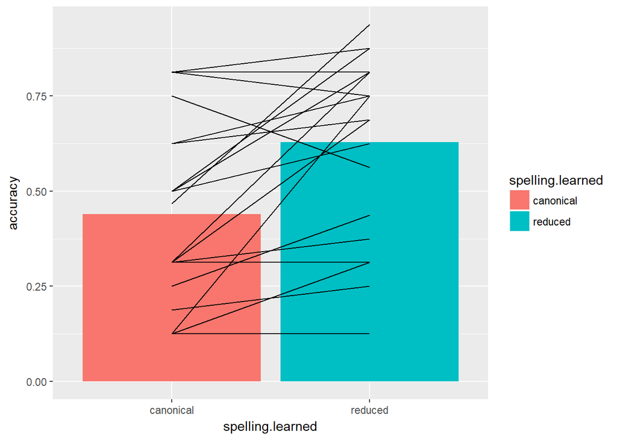

#### Analyses:

Model with spelling.learned as a fixed factor:

```
## Generalized linear mixed model fit by maximum likelihood (Laplace
##   Approximation) [glmerMod]
##  Family: binomial  ( logit )
## Formula: accuracy ~ spelling.learned + (1 | ID) + (1 | item)
##    Data: CR_sess1_criticalTrials
##
##      AIC      BIC   logLik deviance df.resid
##      776      794     -384      768      635
##
## Scaled residuals:
##    Min     1Q Median     3Q    Max
## -3.835 -0.736  0.344  0.705  2.899
##
## Random effects:
##  Groups Name        Variance Std.Dev.
##  item   (Intercept) 0.547    0.74
##  ID     (Intercept) 1.031    1.02
## Number of obs: 639, groups:  item, 32; ID, 20
##
## Fixed effects:
##                         Estimate Std. Error z value Pr(>|z|)
## (Intercept)               -0.338      0.320   -1.06   0.2912
## spelling.learnedreduced    1.014      0.322    3.15   0.0016 **
## ---
## Signif. codes:  0 '***' 0.001 '**' 0.01 '*' 0.05 '.' 0.1 ' ' 1
##
## Correlation of Fixed Effects:
##             (Intr)
## spllng.lrnd -0.495
```

Model without fixed factor:

```
## Generalized linear mixed model fit by maximum likelihood (Laplace
##   Approximation) [glmerMod]
##  Family: binomial  ( logit )
## Formula: accuracy ~ (1 | ID) + (1 | item)
##    Data: CR_sess1_criticalTrials
##
##      AIC      BIC   logLik deviance df.resid
##      783      796     -388      777      636
##
## Scaled residuals:
##    Min     1Q Median     3Q    Max
## -3.751 -0.738  0.359  0.704  2.714
##
## Random effects:
##  Groups Name        Variance Std.Dev.
##  item   (Intercept) 0.805    0.897
##  ID     (Intercept) 1.033    1.016
## Number of obs: 639, groups:  item, 32; ID, 20
##
## Fixed effects:
##             Estimate Std. Error z value Pr(>|z|)
## (Intercept)    0.167      0.292    0.57     0.57
```

Comparing the two:

```
## Data: CR_sess1_criticalTrials
## Models:
## CR.mod0: accuracy ~ (1 | ID) + (1 | item)
## CR.mod1: accuracy ~ spelling.learned + (1 | ID) + (1 | item)
##         Df AIC BIC logLik deviance Chisq Chi Df Pr(>Chisq)
## CR.mod0  3 783 796   -388      777
## CR.mod1  4 776 794   -384      768  8.83      1      0.003 **
## ---
## Signif. codes:  0 '***' 0.001 '**' 0.01 '*' 0.05 '.' 0.1 ' ' 1
```

### Generalization: Mean accuracy on the no spelling items in the Canonical_none and Reduced_none groups - Session 1

Here we are testing whether the items that were not learned with any accompanying spelling inherited the properties of the items learned with a spelling. In other words we’re looking whether there were generalization.

#### Means:

```r
#subset of the "no spelling" trias in group Canonical_none and Reduced_None
CNRN.sess1_criticalTrials <-exp2_session1_canonical[exp2_session1_canonical$group %in% c("Canonical_None", "Reduced_None"),]
CNRN.sess1_noSpellingTrials <- CNRN.sess1_criticalTrials[CNRN.sess1_criticalTrials$spelling.learned %in% c("none"),]
#summary(CNRN_noSpellingTrials)

#means
CNRN_none.sess1.means <- aggregate(accuracy ~ group, CNRN.sess1_noSpellingTrials, FUN="mean")
CNRN_none.sess1.means
```

```
##            group accuracy
## 1 Canonical_None     0.56
## 2   Reduced_None     0.68
```

#### Plot:

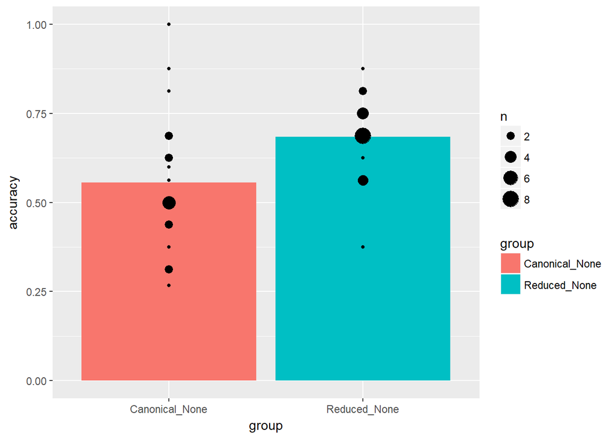

#### Analyses of accuracy on “no spelling” trials - Session 1:

Model with group as a fixed factor:

```
## Generalized linear mixed model fit by maximum likelihood (Laplace
##   Approximation) [glmerMod]
##  Family: binomial  ( logit )
## Formula: accuracy ~ group + (1 | ID) + (1 | item)
##    Data: CNRN.sess1_noSpellingTrials
##
##      AIC      BIC   logLik deviance df.resid
##      754      771     -373      746      634
##
## Scaled residuals:
##    Min     1Q Median     3Q    Max
## -3.121 -0.714  0.385  0.579  2.409
##
## Random effects:
##  Groups Name        Variance Std.Dev.
##  ID     (Intercept) 0.391    0.625
##  item   (Intercept) 1.363    1.167
## Number of obs: 638, groups:  ID, 40; item, 32
##
## Fixed effects:
##                   Estimate Std. Error z value Pr(>|z|)
## (Intercept)          0.317      0.349    0.91     0.36
## groupReduced_None    0.689      0.498    1.38     0.17
##
## Correlation of Fixed Effects:
##             (Intr)
## gropRdcd_Nn -0.700
```

[output not shown]

Model without the fixed factor:

```r
CNRN_none.mod0<-glmer(accuracy ~ (1|ID) + (1|item), CNRN.sess1_noSpellingTrials, family="binomial")
summary(CNRN_none.mod0)
```

```
## Generalized linear mixed model fit by maximum likelihood (Laplace
##   Approximation) [glmerMod]
##  Family: binomial  ( logit )
## Formula: accuracy ~ (1 | ID) + (1 | item)
##    Data: CNRN.sess1_noSpellingTrials
##
##      AIC      BIC   logLik deviance df.resid
##      753      767     -374      747      635
##
## Scaled residuals:
##    Min     1Q Median     3Q    Max
## -3.034 -0.723  0.386  0.589  2.541
##
## Random effects:
##  Groups Name        Variance Std.Dev.
##  ID     (Intercept) 0.408    0.639
##  item   (Intercept) 1.456    1.207
## Number of obs: 638, groups:  ID, 40; item, 32
##
## Fixed effects:
##             Estimate Std. Error z value Pr(>|z|)
## (Intercept)    0.660      0.256    2.58     0.01 **
## ---
## Signif. codes:  0 '***' 0.001 '**' 0.01 '*' 0.05 '.' 0.1 ' ' 1
```

Comparing the two:

```r
anova(CNRN_none.mod1, CNRN_none.mod0)
```

```
## Data: CNRN.sess1_noSpellingTrials
## Models:
## CNRN_none.mod0: accuracy ~ (1 | ID) + (1 | item)
## CNRN_none.mod1: accuracy ~ group + (1 | ID) + (1 | item)
##                Df AIC BIC logLik deviance Chisq Chi Df Pr(>Chisq)
## CNRN_none.mod0  3 753 767   -374      747
## CNRN_none.mod1  4 753 771   -373      745  1.86      1       0.17
```

### Interaction between learning context and accuracy?

Comparing the difference between the Canonical_None canonical spelling trials performance and Reduced_None reduced spelling trials performance to the difference between the Canonical_Reduced canonical spelling trials and reduced spelling trials.

To be able to do this analysis I created a new variable called “learning condition”.  
This variable has two levels: consistent or inconsistent.  
In Group 1 and 2, I call the learning “consistent” because the rules listeners had to learn were simple:  
- **Group 1: when a word has a spelling**  
-intervocalic flap is always spelled “tt” (bytto)  
-nasal flap is always spelled “nt” (sento)  
- **Group 2: when a word has a spelling**  
-intervocalic flap is always spelled “dd” (cluddee)  
-nasal flap is always spelled “nn” (trenner)

In **Group 3** I call the learning “inconsistent” because the rules were more complicated:  
- intervocalic flap is spelled “tt” or “dd”  
- nasal flap is spelled “nt” or “nt”

#### Means:

```
##   learning spelling.learned accuracy   sd  sem
## 1   simple        canonical     0.41 0.49 0.11
## 2  complex        canonical     0.44 0.50 0.11
## 3   simple          reduced     0.71 0.45 0.10
## 4  complex          reduced     0.63 0.48 0.11
```

#### Plot

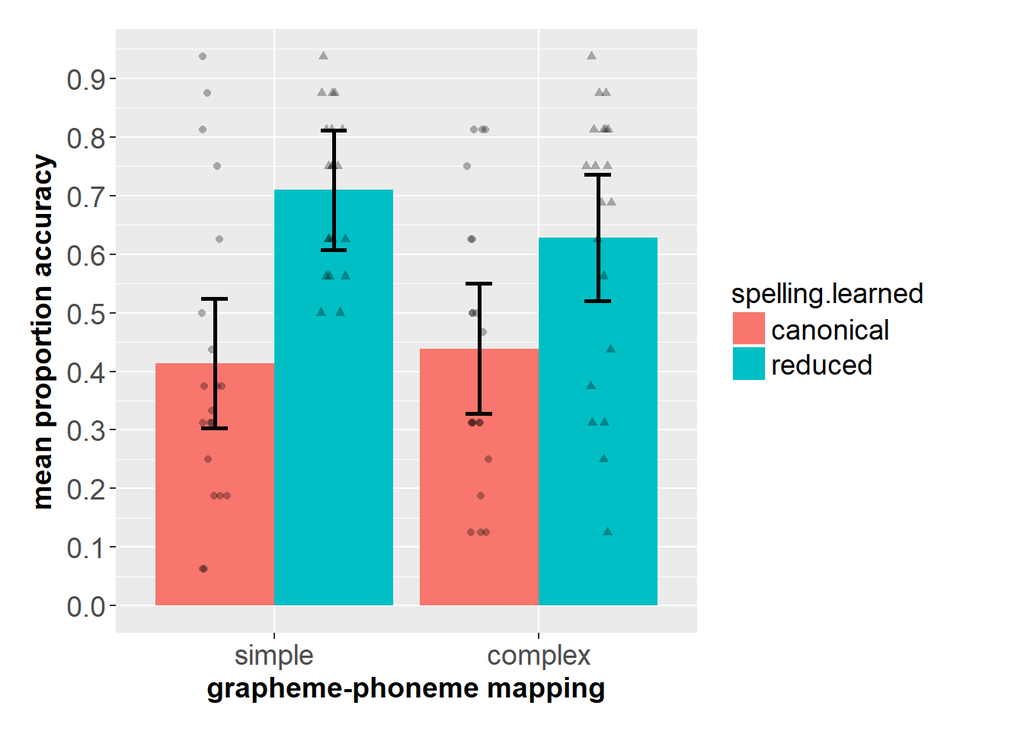

#### Analyses of the interaction between learning context and effect of orthography (Session 1)

Model with interaction:

```r
learning.mod1 <- glmer(accuracy ~ learning/spelling.learned + (1|ID)+
                         (1|item),exp2_session1_interaction, family="binomial")

summary(learning.mod1)
```

```
## Generalized linear mixed model fit by maximum likelihood (Laplace
##   Approximation) [glmerMod]
##  Family: binomial  ( logit )
## Formula: accuracy ~ learning/spelling.learned + (1 | ID) + (1 | item)
##    Data: exp2_session1_interaction
##
##      AIC      BIC   logLik deviance df.resid
##     1500     1531     -744     1488     1272
##
## Scaled residuals:
##    Min     1Q Median     3Q    Max
## -4.230 -0.693  0.317  0.643  3.480
##
## Random effects:
##  Groups Name        Variance Std.Dev.
##  ID     (Intercept) 0.965    0.982
##  item   (Intercept) 0.660    0.813
## Number of obs: 1278, groups:  ID, 60; item, 32
##
## Fixed effects:
##                                         Estimate Std. Error z value
## (Intercept)                               -0.441      0.327   -1.35
## learningcomplex                            0.100      0.361    0.28
## learningsimple:spelling.learnedreduced     1.584      0.466    3.40
## learningcomplex:spelling.learnedreduced    1.030      0.344    3.00
##                                         Pr(>|z|)
## (Intercept)                              0.17751
## learningcomplex                          0.78125
## learningsimple:spelling.learnedreduced   0.00068 ***
## learningcomplex:spelling.learnedreduced  0.00272 **
## ---
## Signif. codes:  0 '***' 0.001 '**' 0.01 '*' 0.05 '.' 0.1 ' ' 1
##
## Correlation of Fixed Effects:
##             (Intr) lrnngc lrnngs:.
## lernngcmplx -0.556
## lrnngsmpl:. -0.703  0.390
## lrnngcmpl:. -0.369 -0.134  0.521
```

Model without interaction:

```r
learning.mod0 <-glmer(accuracy~learning+spelling.learned+(1|ID)+(1|item), data=exp2_session1_interaction, family="binomial")
summary(learning.mod0)
```

```
## Generalized linear mixed model fit by maximum likelihood (Laplace
##   Approximation) [glmerMod]
##  Family: binomial  ( logit )
## Formula: accuracy ~ learning + spelling.learned + (1 | ID) + (1 | item)
##    Data: exp2_session1_interaction
##
##      AIC      BIC   logLik deviance df.resid
##     1500     1526     -745     1490     1273
##
## Scaled residuals:
##    Min     1Q Median     3Q    Max
## -4.387 -0.695  0.318  0.651  3.623
##
## Random effects:
##  Groups Name        Variance Std.Dev.
##  ID     (Intercept) 0.994    0.997
##  item   (Intercept) 0.659    0.812
## Number of obs: 1278, groups:  ID, 60; item, 32
##
## Fixed effects:
##                         Estimate Std. Error z value Pr(>|z|)
## (Intercept)               -0.225      0.287   -0.79  0.43151
## learningcomplex           -0.171      0.304   -0.56  0.57490
## spelling.learnedreduced    1.146      0.333    3.44  0.00058 ***
## ---
## Signif. codes:  0 '***' 0.001 '**' 0.01 '*' 0.05 '.' 0.1 ' ' 1
##
## Correlation of Fixed Effects:
##             (Intr) lrnngc
## lernngcmplx -0.393
## spllng.lrnd -0.577  0.004
```

Comparing the two:

```r
anova(learning.mod0, learning.mod1)
```

```
## Data: exp2_session1_interaction
## Models:
## learning.mod0: accuracy ~ learning + spelling.learned + (1 | ID) + (1 | item)
## learning.mod1: accuracy ~ learning/spelling.learned + (1 | ID) + (1 | item)
##               Df  AIC  BIC logLik deviance Chisq Chi Df Pr(>Chisq)
## learning.mod0  5 1500 1526   -745     1490
## learning.mod1  6 1500 1531   -744     1488  1.79      1       0.18
```

## ACCURACY ANALYSES: EXPERIMENT 2, SESSION 2 - CONSOLIDATION EFFECT?

### Effect of consolidation? Comparing Sessino 1 and 2 of Experiment 2.

The analysis described here were meant to evaluate whether allowing listeners to sleep between sessions changed the result pattern observed in Experiment 1 and Experiment 2 - Session 1.  
In other words we are comparing performance on Experiment 2 Session 1 and Experiment 2 Session 2.

Data frame

```r
##subset data to get test 1 and test 2 performanceexp
exp2_consolidation<-exp2_canonical[exp2_canonical$session %in% c("session 1", "session 2"),]
#summary(exp2_consolidation)
```

#### Means:

```
##    spelling.learned   session             group accuracy
## 1         canonical session 1    Canonical_None     0.41
## 2              none session 1    Canonical_None     0.56
## 3         canonical session 2    Canonical_None     0.43
## 4              none session 2    Canonical_None     0.54
## 5         canonical session 1 Canonical_Reduced     0.44
## 6           reduced session 1 Canonical_Reduced     0.63
## 7         canonical session 2 Canonical_Reduced     0.49
## 8           reduced session 2 Canonical_Reduced     0.60
## 9              none session 1      Reduced_None     0.68
## 10          reduced session 1      Reduced_None     0.71
## 11             none session 2      Reduced_None     0.66
## 12          reduced session 2      Reduced_None     0.74
```

#### Plot:

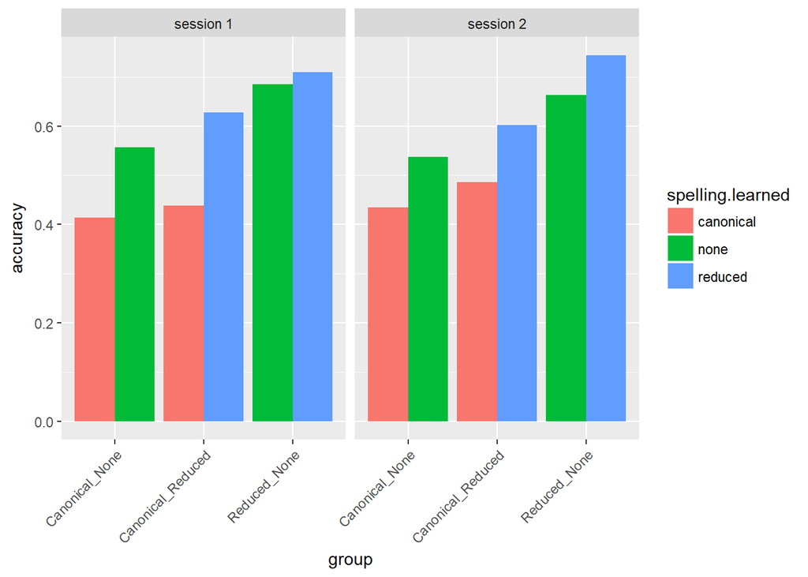

#### Analysis comparing session 1 and 2:

Comparing performance on the two session

Main model:

```r
consolidation.mod1<-glmer(accuracy~group+spelling.learned+session+(1|ID)+(1|item), exp2_consolidation, family="binomial")

summary(consolidation.mod1)
```

```
## Generalized linear mixed model fit by maximum likelihood (Laplace
##   Approximation) [glmerMod]
##  Family: binomial  ( logit )
## Formula: accuracy ~ group + spelling.learned + session + (1 | ID) + (1 |
##     item)
##    Data: exp2_consolidation
##
##      AIC      BIC   logLik deviance df.resid
##     4348     4398    -2166     4332     3821
##
## Scaled residuals:
##    Min     1Q Median     3Q    Max
## -4.107 -0.727  0.333  0.663  4.461
##
## Random effects:
##  Groups Name        Variance Std.Dev.
##  ID     (Intercept) 0.868    0.932
##  item   (Intercept) 0.681    0.825
## Number of obs: 3829, groups:  ID, 60; item, 32
##
## Fixed effects:
##                         Estimate Std. Error z value Pr(>|z|)
## (Intercept)              -0.3140     0.2778   -1.13   0.2584
## groupCanonical_Reduced    0.1272     0.3191    0.40   0.6901
## groupReduced_None         0.6736     0.3370    2.00   0.0457 *
## spelling.learnednone      0.5329     0.1628    3.27   0.0011 **
## spelling.learnedreduced   0.7661     0.2638    2.90   0.0037 **
## sessionsession 2          0.0357     0.0759    0.47   0.6378
## ---
## Signif. codes:  0 '***' 0.001 '**' 0.01 '*' 0.05 '.' 0.1 ' ' 1
##
## Correlation of Fixed Effects:
##              (Intr) grpC_R grpR_N spllng.lrndn spllng.lrndr
## grpCnncl_Rd  -0.516
## gropRdcd_Nn  -0.415  0.521
## spllng.lrndn -0.293 -0.078 -0.328
## spllng.lrndr -0.240 -0.198 -0.394  0.817
## sessinsssn2  -0.137  0.001  0.001  0.001        0.001
```

Base model:

```r
consolidation.mod0<-glmer(accuracy~group+spelling.learned+(1|ID)+(1|item), exp2_consolidation, family="binomial")
summary(consolidation.mod0)
```

```
## Generalized linear mixed model fit by maximum likelihood (Laplace
##   Approximation) [glmerMod]
##  Family: binomial  ( logit )
## Formula: accuracy ~ group + spelling.learned + (1 | ID) + (1 | item)
##    Data: exp2_consolidation
##
##      AIC      BIC   logLik deviance df.resid
##     4347     4390    -2166     4333     3822
##
## Scaled residuals:
##    Min     1Q Median     3Q    Max
## -4.143 -0.723  0.333  0.664  4.500
##
## Random effects:
##  Groups Name        Variance Std.Dev.
##  ID     (Intercept) 0.868    0.932
##  item   (Intercept) 0.681    0.825
## Number of obs: 3829, groups:  ID, 60; item, 32
##
## Fixed effects:
##                         Estimate Std. Error z value Pr(>|z|)
## (Intercept)               -0.296      0.275   -1.08   0.2820
## groupCanonical_Reduced     0.127      0.319    0.40   0.6906
## groupReduced_None          0.673      0.337    2.00   0.0456 *
## spelling.learnednone       0.533      0.163    3.27   0.0011 **
## spelling.learnedreduced    0.766      0.264    2.90   0.0037 **
## ---
## Signif. codes:  0 '***' 0.001 '**' 0.01 '*' 0.05 '.' 0.1 ' ' 1
##
## Correlation of Fixed Effects:
##              (Intr) grpC_R grpR_N spllng.lrndn
## grpCnncl_Rd  -0.521
## gropRdcd_Nn  -0.419  0.521
## spllng.lrndn -0.295 -0.078 -0.328
## spllng.lrndr -0.242 -0.198 -0.393  0.817
```

Comparing the two:

```r
anova(consolidation.mod1, consolidation.mod0)
```

```
## Data: exp2_consolidation
## Models:
## consolidation.mod0: accuracy ~ group + spelling.learned + (1 | ID) + (1 | item)
## consolidation.mod1: accuracy ~ group + spelling.learned + session + (1 | ID) + (1 |
## consolidation.mod1:     item)
##                    Df  AIC  BIC logLik deviance Chisq Chi Df Pr(>Chisq)
## consolidation.mod0  7 4347 4390  -2166     4333
## consolidation.mod1  8 4348 4398  -2166     4332  0.22      1       0.64
```

There is no effect of Session, indicating that the 2 days delay did not affect people’s performance or change the effect fo orthography on the perception of the pronunciation variants.

## ACCURACY ANALYSIS: EXPERIMENT 2 SESSION 2

Data frame:

```r
##critical trial, session 1 only:

exp2_session2_canonical<-exp2_canonical[exp2_canonical$session == "session 2",]
```

### Main effect of Spelling in Session 2?

Mean accuracy for the critical items for each spelling learned

#### Means:

```r
main_spelling.sess2.learned<-aggregate(accuracy~spelling.learned, exp2_session2_canonical, FUN="mean")
main_spelling.sess2.learned
```

```
##   spelling.learned accuracy
## 1        canonical     0.46
## 2             none     0.60
## 3          reduced     0.67
```

#### Analysis for the main effect of Spelling in Session 2.

Model with spelling.learned as a fixed factor

```r
spell_sess2.mod1<-glmer(accuracy~spelling.learned+(1|ID)+(1|item), data=exp2_session2_canonical, family="binomial")
summary(spell_sess2.mod1)
```

```
## Generalized linear mixed model fit by maximum likelihood (Laplace
##   Approximation) [glmerMod]
##  Family: binomial  ( logit )
## Formula: accuracy ~ spelling.learned + (1 | ID) + (1 | item)
##    Data: exp2_session2_canonical
##
##      AIC      BIC   logLik deviance df.resid
##     2203     2231    -1097     2193     1908
##
## Scaled residuals:
##    Min     1Q Median     3Q    Max
## -4.925 -0.715  0.313  0.655  3.915
##
## Random effects:
##  Groups Name        Variance Std.Dev.
##  ID     (Intercept) 1.269    1.13
##  item   (Intercept) 0.641    0.80
## Number of obs: 1913, groups:  ID, 60; item, 32
##
## Fixed effects:
##                         Estimate Std. Error z value Pr(>|z|)
## (Intercept)               0.0171     0.2627    0.06   0.9482
## spelling.learnednone      0.4624     0.1990    2.32   0.0201 *
## spelling.learnedreduced   0.8132     0.3008    2.70   0.0069 **
## ---
## Signif. codes:  0 '***' 0.001 '**' 0.01 '*' 0.05 '.' 0.1 ' ' 1
##
## Correlation of Fixed Effects:
##              (Intr) spllng.lrndn
## spllng.lrndn -0.544
## spllng.lrndr -0.572  0.754
```

Model without fixed factor

```r
##base model
spell_sess2.mod0<-glmer(accuracy~(1|ID)+(1|item), data=exp2_session2_canonical, family="binomial")
summary(spell_sess2.mod0)
```

```
## Generalized linear mixed model fit by maximum likelihood (Laplace
##   Approximation) [glmerMod]
##  Family: binomial  ( logit )
## Formula: accuracy ~ (1 | ID) + (1 | item)
##    Data: exp2_session2_canonical
##
##      AIC      BIC   logLik deviance df.resid
##     2206     2223    -1100     2200     1910
##
## Scaled residuals:
##    Min     1Q Median     3Q    Max
## -5.143 -0.721  0.317  0.654  3.962
##
## Random effects:
##  Groups Name        Variance Std.Dev.
##  ID     (Intercept) 1.414    1.189
##  item   (Intercept) 0.728    0.853
## Number of obs: 1913, groups:  ID, 60; item, 32
##
## Fixed effects:
##             Estimate Std. Error z value Pr(>|z|)
## (Intercept)    0.446      0.223    2.01    0.045 *
## ---
## Signif. codes:  0 '***' 0.001 '**' 0.01 '*' 0.05 '.' 0.1 ' ' 1
```

Comparing the two

```r
##Likelihood test
anova(spell_sess2.mod0,spell_sess2.mod1)
```

```
## Data: exp2_session2_canonical
## Models:
## spell_sess2.mod0: accuracy ~ (1 | ID) + (1 | item)
## spell_sess2.mod1: accuracy ~ spelling.learned + (1 | ID) + (1 | item)
##                  Df  AIC  BIC logLik deviance Chisq Chi Df Pr(>Chisq)
## spell_sess2.mod0  3 2206 2223  -1100     2200
## spell_sess2.mod1  5 2203 2231  -1097     2193  7.18      2      0.028 *
## ---
## Signif. codes:  0 '***' 0.001 '**' 0.01 '*' 0.05 '.' 0.1 ' ' 1
```

Relevel the first model (i.e. change reference level) to get all the comparisons:

```r
##relevel to get all the comparisons between spellings:
spell_relevel<-within(exp2_session2_canonical, spelling.learned <- relevel(spelling.learned, ref = 3))

spell.mod3_rlvl<-glmer(accuracy~spelling.learned+(1|ID)+(1|item), data=spell_relevel, family="binomial")
summary(spell.mod3_rlvl)
```

```
## Generalized linear mixed model fit by maximum likelihood (Laplace
##   Approximation) [glmerMod]
##  Family: binomial  ( logit )
## Formula: accuracy ~ spelling.learned + (1 | ID) + (1 | item)
##    Data: spell_relevel
##
##      AIC      BIC   logLik deviance df.resid
##     2203     2231    -1097     2193     1908
##
## Scaled residuals:
##    Min     1Q Median     3Q    Max
## -4.925 -0.715  0.313  0.655  3.915
##
## Random effects:
##  Groups Name        Variance Std.Dev.
##  ID     (Intercept) 1.269    1.13
##  item   (Intercept) 0.641    0.80
## Number of obs: 1913, groups:  ID, 60; item, 32
##
## Fixed effects:
##                           Estimate Std. Error z value Pr(>|z|)
## (Intercept)                  0.479      0.227    2.11    0.035 *
## spelling.learnedcanonical   -0.462      0.199   -2.32    0.020 *
## spelling.learnedreduced      0.351      0.199    1.76    0.079 .
## ---
## Signif. codes:  0 '***' 0.001 '**' 0.01 '*' 0.05 '.' 0.1 ' ' 1
##
## Correlation of Fixed Effects:
##              (Intr) spllng.lrndc
## spllng.lrndc -0.246
## spllng.lrndr -0.247 -0.140
```

### Direct test of hypothesis in Session 2: accuracy in group Canonical_Reduced

Participants in thiss group leanred half the words with a canonical spelling and half with a reduced spelling.  
A difference in performance would indicate and effect of orthography.

```r
##subset:
exp2_session2_CR<-exp2_session2_canonical[exp2_session2_canonical$group %in% c("Canonical_Reduced"),]
#summary(exp2_session2_CR)
```

#### Means:

```
##   spelling.learned accuracy
## 1        canonical     0.49
## 2          reduced     0.60
```

#### Plot:

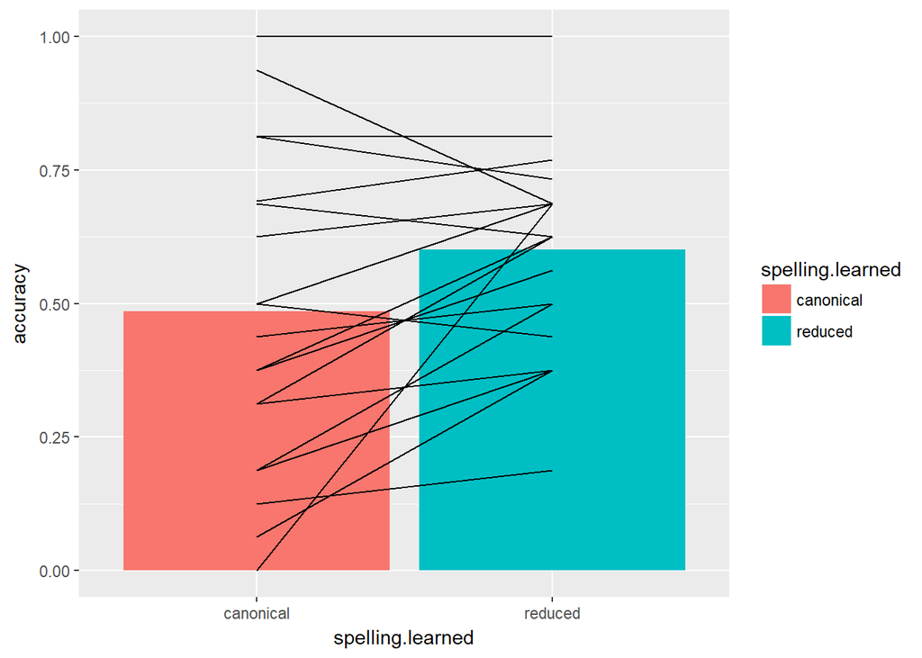

```r
CR_sess2.bySubject <- aggregate(accuracy~ID+spelling.learned,exp2_session2_CR, FUN="mean")


ggplot(CR_sess2.means, aes(spelling.learned, accuracy))+
  geom_bar(stat="identity", position="dodge", aes(fill=spelling.learned))+
  geom_line(data=CR_sess2.bySubject, aes(group=ID, x=spelling.learned, y=accuracy))
```

####Analysis: Effect of Orthography within the Canonical_Reduced group in Session 2

Model with fixed effect

```r
CR.sess2.mod1<-glmer(accuracy ~ spelling.learned + (1|ID) + (1|item), exp2_session2_CR, family="binomial")

summary(CR.sess2.mod1)
```

```
## Generalized linear mixed model fit by maximum likelihood (Laplace
##   Approximation) [glmerMod]
##  Family: binomial  ( logit )
## Formula: accuracy ~ spelling.learned + (1 | ID) + (1 | item)
##    Data: exp2_session2_CR
##
##      AIC      BIC   logLik deviance df.resid
##      762      779     -377      754      629
##
## Scaled residuals:
##    Min     1Q Median     3Q    Max
## -2.830 -0.703  0.256  0.692  2.269
##
## Random effects:
##  Groups Name        Variance Std.Dev.
##  item   (Intercept) 0.588    0.767
##  ID     (Intercept) 1.468    1.212
## Number of obs: 633, groups:  item, 32; ID, 20
##
## Fixed effects:
##                         Estimate Std. Error z value Pr(>|z|)
## (Intercept)              -0.0388     0.3574   -0.11    0.913
## spelling.learnedreduced   0.6557     0.3304    1.98    0.047 *
## ---
## Signif. codes:  0 '***' 0.001 '**' 0.01 '*' 0.05 '.' 0.1 ' ' 1
##
## Correlation of Fixed Effects:
##             (Intr)
## spllng.lrnd -0.454
```

Base model:

```r
CR.sess2.mod0<-glmer(accuracy ~ (1|ID) + (1|item), exp2_session2_CR, family="binomial")
summary(CR.sess2.mod0)
```

```
## Generalized linear mixed model fit by maximum likelihood (Laplace
##   Approximation) [glmerMod]
##  Family: binomial  ( logit )
## Formula: accuracy ~ (1 | ID) + (1 | item)
##    Data: exp2_session2_CR
##
##      AIC      BIC   logLik deviance df.resid
##      763      777     -379      757      630
##
## Scaled residuals:
##    Min     1Q Median     3Q    Max
## -2.722 -0.727  0.266  0.703  2.249
##
## Random effects:
##  Groups Name        Variance Std.Dev.
##  item   (Intercept) 0.693    0.832
##  ID     (Intercept) 1.470    1.212
## Number of obs: 633, groups:  item, 32; ID, 20
##
## Fixed effects:
##             Estimate Std. Error z value Pr(>|z|)
## (Intercept)    0.288      0.324    0.89     0.37
```

Comparing the two:

```r
anova(CR.sess2.mod0, CR.sess2.mod1)
```

```
## Data: exp2_session2_CR
## Models:
## CR.sess2.mod0: accuracy ~ (1 | ID) + (1 | item)
## CR.sess2.mod1: accuracy ~ spelling.learned + (1 | ID) + (1 | item)
##               Df AIC BIC logLik deviance Chisq Chi Df Pr(>Chisq)
## CR.sess2.mod0  3 763 777   -379      757
## CR.sess2.mod1  4 762 779   -377      754  3.76      1      0.053 .
## ---
## Signif. codes:  0 '***' 0.001 '**' 0.01 '*' 0.05 '.' 0.1 ' ' 1
```

### Generalization to the items that did not receive a spelling? (Session 2)

Data:

```r
exp2_session2_CNRN <-exp2_session2_canonical[exp2_session2_canonical$group %in% c("Canonical_None", "Reduced_None"),]
exp2_session2_CNRN<-exp2_session2_CNRN[exp2_session2_CNRN$spelling.learned == "none",]
```

#### Means:

```
##            group accuracy
## 1 Canonical_None     0.54
## 2   Reduced_None     0.66
```

#### Plot:

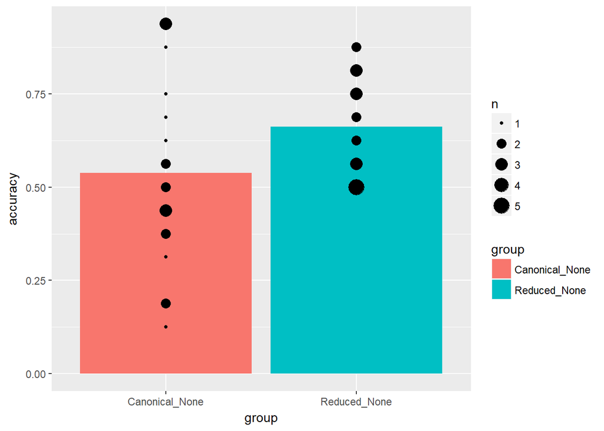

#### Analysis: Difference between the Canonical_None and Reduced_None groups for the no spelling items?

Model with fixed effect:

```
## Generalized linear mixed model fit by maximum likelihood (Laplace
##   Approximation) [glmerMod]
##  Family: binomial  ( logit )
## Formula: accuracy ~ group + (1 | ID) + (1 | item)
##    Data: exp2_session2_CNRN
##
##      AIC      BIC   logLik deviance df.resid
##      785      803     -388      777      636
##
## Scaled residuals:
##    Min     1Q Median     3Q    Max
## -3.198 -0.784  0.403  0.634  2.083
##
## Random effects:
##  Groups Name        Variance Std.Dev.
##  ID     (Intercept) 0.852    0.923
##  item   (Intercept) 0.804    0.897
## Number of obs: 640, groups:  ID, 40; item, 32
##
## Fixed effects:
##                   Estimate Std. Error z value Pr(>|z|)
## (Intercept)          0.222      0.332    0.67     0.50
## groupReduced_None    0.630      0.471    1.34     0.18
##
## Correlation of Fixed Effects:
##             (Intr)
## gropRdcd_Nn -0.705
```

THere were no generalization effects in Session 2.

### Interaction between learning context and effect of orthography?

Data:

```r
exp2_session2_interaction<-exp2_session2_canonical
exp2_session2_interaction <- exp2_session2_interaction[exp2_session2_interaction$spelling.learned %in% c("canonical", "reduced"),]

##creating the new variable:
exp2_session2_interaction$learning<-exp2_session2_interaction$group
exp2_session2_interaction$learning<-revalue(exp2_session2_interaction$learning, c("Canonical_None"="simple",
                                     "Reduced_None"="simple",
                                     "Canonical_Reduced" = "complex"))
```

#### Means:

```
##   spelling.learned learning accuracy
## 1        canonical   simple     0.43
## 2          reduced   simple     0.74
## 3        canonical  complex     0.49
## 4          reduced  complex     0.60
```

#### Plot:

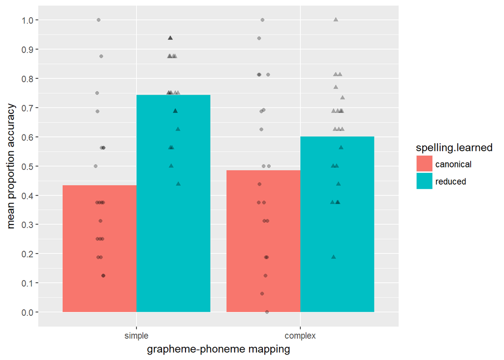

#### Analysis: Interaction between learning context and orthography effect? (Session 2)

Main model:

```r
sess2_interaction.mod1 <-glmer(accuracy ~ learning/spelling.learned + (1|ID)+(1|item), exp2_session2_interaction, family="binomial")
summary(sess2_interaction.mod1)
```

```
## Generalized linear mixed model fit by maximum likelihood (Laplace
##   Approximation) [glmerMod]
##  Family: binomial  ( logit )
## Formula: accuracy ~ learning/spelling.learned + (1 | ID) + (1 | item)
##    Data: exp2_session2_interaction
##
##      AIC      BIC   logLik deviance df.resid
##     1487     1518     -738     1475     1267
##
## Scaled residuals:
##    Min     1Q Median     3Q    Max
## -4.535 -0.697  0.296  0.663  2.458
##
## Random effects:
##  Groups Name        Variance Std.Dev.
##  ID     (Intercept) 1.111    1.054
##  item   (Intercept) 0.617    0.785
## Number of obs: 1273, groups:  ID, 60; item, 32
##
## Fixed effects:
##                                         Estimate Std. Error z value
## (Intercept)                               -0.319      0.334   -0.96
## learningcomplex                            0.272      0.381    0.71
## learningsimple:spelling.learnedreduced     1.707      0.478    3.57
## learningcomplex:spelling.learnedreduced    0.654      0.335    1.95
##                                         Pr(>|z|)
## (Intercept)                              0.33816
## learningcomplex                          0.47522
## learningsimple:spelling.learnedreduced   0.00035 ***
## learningcomplex:spelling.learnedreduced  0.05102 .
## ---
## Signif. codes:  0 '***' 0.001 '**' 0.01 '*' 0.05 '.' 0.1 ' ' 1
##
## Correlation of Fixed Effects:
##             (Intr) lrnngc lrnngs:.
## lernngcmplx -0.571
## lrnngsmpl:. -0.698  0.399
## lrnngcmpl:. -0.346 -0.130  0.487
```

Base model:

```r
sess2_interaction.mod0 <-glmer(accuracy ~ learning+spelling.learned + (1|ID)+(1|item), exp2_session2_interaction, family="binomial")
summary(sess2_interaction.mod0)
```

```
## Generalized linear mixed model fit by maximum likelihood (Laplace
##   Approximation) [glmerMod]
##  Family: binomial  ( logit )
## Formula: accuracy ~ learning + spelling.learned + (1 | ID) + (1 | item)
##    Data: exp2_session2_interaction
##
##      AIC      BIC   logLik deviance df.resid
##     1491     1517     -740     1481     1268
##
## Scaled residuals:
##    Min     1Q Median     3Q    Max
## -4.265 -0.708  0.304  0.653  2.423
##
## Random effects:
##  Groups Name        Variance Std.Dev.
##  ID     (Intercept) 1.232    1.110
##  item   (Intercept) 0.613    0.783
## Number of obs: 1273, groups:  ID, 60; item, 32
##
## Fixed effects:
##                         Estimate Std. Error z value Pr(>|z|)
## (Intercept)                0.103      0.293    0.35   0.7259
## learningcomplex           -0.239      0.333   -0.72   0.4740
## spelling.learnedreduced    0.846      0.326    2.59   0.0095 **
## ---
## Signif. codes:  0 '***' 0.001 '**' 0.01 '*' 0.05 '.' 0.1 ' ' 1
##
## Correlation of Fixed Effects:
##             (Intr) lrnngc
## lernngcmplx -0.414
## spllng.lrnd -0.552  0.002
```

Comparing the two:

```r
anova(sess2_interaction.mod0, sess2_interaction.mod1) # interaction significant here
```

```
## Data: exp2_session2_interaction
## Models:
## sess2_interaction.mod0: accuracy ~ learning + spelling.learned + (1 | ID) + (1 | item)
## sess2_interaction.mod1: accuracy ~ learning/spelling.learned + (1 | ID) + (1 | item)
##                        Df  AIC  BIC logLik deviance Chisq Chi Df
## sess2_interaction.mod0  5 1491 1517   -740     1481
## sess2_interaction.mod1  6 1487 1518   -738     1475   5.8      1
##                        Pr(>Chisq)
## sess2_interaction.mod0
## sess2_interaction.mod1      0.016 *
## ---
## Signif. codes:  0 '***' 0.001 '**' 0.01 '*' 0.05 '.' 0.1 ' ' 1
```

## ACCURACY ANALYSIS: SESSION 3 - EFFECT OF ADDITIONAL EXPOSURE?

Session 3 occured after additional exposure to the picture-word pairs (i.e. the variant pronunciations of the new words and their associated object)

### Comparing session 2 and session 3

Data set:

```r
session.2_3<-exp2_canonical[exp2_canonical$session %in% c("session 2", "session 3"),]
#summary(session.2_3)
```

#### Means

```
##    spelling.learned   session             group accuracy
## 1         canonical session 2    Canonical_None     0.43
## 2              none session 2    Canonical_None     0.54
## 3         canonical session 3    Canonical_None     0.49
## 4              none session 3    Canonical_None     0.61
## 5         canonical session 2 Canonical_Reduced     0.49
## 6           reduced session 2 Canonical_Reduced     0.60
## 7         canonical session 3 Canonical_Reduced     0.51
## 8           reduced session 3 Canonical_Reduced     0.71
## 9              none session 2      Reduced_None     0.66
## 10          reduced session 2      Reduced_None     0.74
## 11             none session 3      Reduced_None     0.72
## 12          reduced session 3      Reduced_None     0.82
```

#### Plot

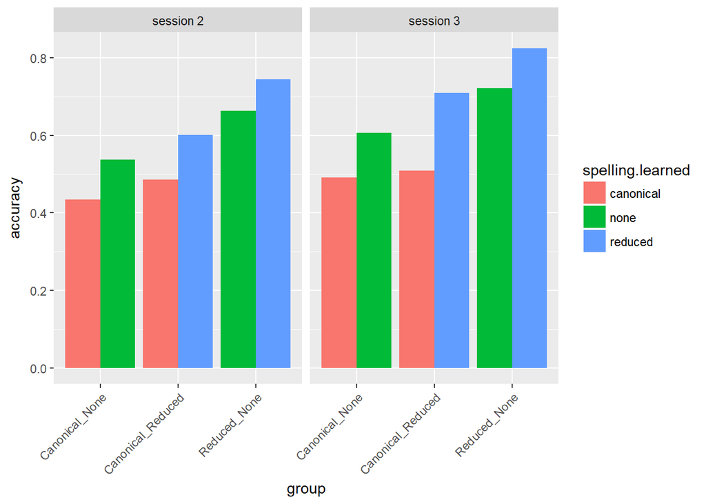

#### Analysis: effect of additional training?

Main model:

```r
session23.mod1<-glmer(accuracy~group+spelling.learned+session+(1|ID)+(1|item), session.2_3, family="binomial")
summary(session23.mod1)
```

```
## Generalized linear mixed model fit by maximum likelihood (Laplace
##   Approximation) [glmerMod]
##  Family: binomial  ( logit )
## Formula: accuracy ~ group + spelling.learned + session + (1 | ID) + (1 |
##     item)
##    Data: session.2_3
##
##      AIC      BIC   logLik deviance df.resid
##     4025     4075    -2005     4009     3824
##
## Scaled residuals:
##    Min     1Q Median     3Q    Max
## -5.644 -0.640  0.292  0.588  6.549
##
## Random effects:
##  Groups Name        Variance Std.Dev.
##  ID     (Intercept) 1.325    1.151
##  item   (Intercept) 0.814    0.902
## Number of obs: 3832, groups:  ID, 60; item, 32
##
## Fixed effects:
##                         Estimate Std. Error z value Pr(>|z|)
## (Intercept)              -0.2689     0.3253   -0.83   0.4083
## groupCanonical_Reduced    0.1673     0.3862    0.43   0.6648
## groupReduced_None         0.8443     0.4043    2.09   0.0368 *
## spelling.learnednone      0.3784     0.1740    2.17   0.0297 *
## spelling.learnedreduced   0.7584     0.2803    2.71   0.0068 **
## sessionsession 3          0.4075     0.0801    5.09  3.6e-07 ***
## ---
## Signif. codes:  0 '***' 0.001 '**' 0.01 '*' 0.05 '.' 0.1 ' ' 1
##
## Correlation of Fixed Effects:
##              (Intr) grpC_R grpR_N spllng.lrndn spllng.lrndr
## grpCnncl_Rd  -0.549
## gropRdcd_Nn  -0.462  0.513
## spllng.lrndn -0.268 -0.066 -0.298
## spllng.lrndr -0.221 -0.168 -0.351  0.820
## sessinsssn3  -0.124  0.001  0.007  0.007        0.008
```

Base model:

```r
session23.mod2<-glmer(accuracy~group+spelling.learned+(1|ID)+(1|item), session.2_3, family="binomial")
summary(session23.mod2)
```

```
## Generalized linear mixed model fit by maximum likelihood (Laplace
##   Approximation) [glmerMod]
##  Family: binomial  ( logit )
## Formula: accuracy ~ group + spelling.learned + (1 | ID) + (1 | item)
##    Data: session.2_3
##
##      AIC      BIC   logLik deviance df.resid
##     4049     4093    -2018     4035     3825
##
## Scaled residuals:
##    Min     1Q Median     3Q    Max
## -5.462 -0.652  0.290  0.593  5.822
##
## Random effects:
##  Groups Name        Variance Std.Dev.
##  ID     (Intercept) 1.3      1.141
##  item   (Intercept) 0.8      0.894
## Number of obs: 3832, groups:  ID, 60; item, 32
##
## Fixed effects:
##                         Estimate Std. Error z value Pr(>|z|)
## (Intercept)              -0.0648     0.3202   -0.20   0.8396
## groupCanonical_Reduced    0.1670     0.3831    0.44   0.6629
## groupReduced_None         0.8371     0.4011    2.09   0.0369 *
## spelling.learnednone      0.3755     0.1732    2.17   0.0301 *
## spelling.learnedreduced   0.7528     0.2788    2.70   0.0069 **
## ---
## Signif. codes:  0 '***' 0.001 '**' 0.01 '*' 0.05 '.' 0.1 ' ' 1
##
## Correlation of Fixed Effects:
##              (Intr) grpC_R grpR_N spllng.lrndn
## grpCnncl_Rd  -0.553
## gropRdcd_Nn  -0.464  0.513
## spllng.lrndn -0.270 -0.066 -0.298
## spllng.lrndr -0.223 -0.169 -0.352  0.820
```

Comparing the two:

```r
anova(session23.mod1, session23.mod2)
```

```
## Data: session.2_3
## Models:
## session23.mod2: accuracy ~ group + spelling.learned + (1 | ID) + (1 | item)
## session23.mod1: accuracy ~ group + spelling.learned + session + (1 | ID) + (1 |
## session23.mod1:     item)
##                Df  AIC  BIC logLik deviance Chisq Chi Df Pr(>Chisq)
## session23.mod2  7 4049 4093  -2018     4035
## session23.mod1  8 4025 4075  -2005     4009  25.8      1    3.9e-07 ***
## ---
## Signif. codes:  0 '***' 0.001 '**' 0.01 '*' 0.05 '.' 0.1 ' ' 1
```

Relevel the main model to get all the comparisons:

```
## Generalized linear mixed model fit by maximum likelihood (Laplace
##   Approximation) [glmerMod]
##  Family: binomial  ( logit )
## Formula: accuracy ~ group + spelling.learned + session + (1 | ID) + (1 |
##     item)
##    Data: session23_relevel
##
##      AIC      BIC   logLik deviance df.resid
##     4025     4075    -2005     4009     3824
##
## Scaled residuals:
##    Min     1Q Median     3Q    Max
## -5.644 -0.640  0.292  0.588  6.549
##
## Random effects:
##  Groups Name        Variance Std.Dev.
##  ID     (Intercept) 1.325    1.151
##  item   (Intercept) 0.814    0.902
## Number of obs: 3832, groups:  ID, 60; item, 32
##
## Fixed effects:
##                           Estimate Std. Error z value Pr(>|z|)
## (Intercept)                 0.1094     0.3252    0.34    0.736
## groupCanonical_Reduced      0.1673     0.3861    0.43    0.665
## groupReduced_None           0.8443     0.4042    2.09    0.037 *
## spelling.learnedcanonical  -0.3784     0.1740   -2.17    0.030 *
## spelling.learnedreduced     0.3800     0.1699    2.24    0.025 *
## sessionsession 3            0.4074     0.0801    5.09  3.6e-07 ***
## ---
## Signif. codes:  0 '***' 0.001 '**' 0.01 '*' 0.05 '.' 0.1 ' ' 1
##
## Correlation of Fixed Effects:
##              (Intr) grpC_R grpR_N spllng.lrndc spllng.lrndr
## grpCnncl_Rd  -0.584
## gropRdcd_Nn  -0.622  0.513
## spllng.lrndc -0.267  0.066  0.298
## spllng.lrndr  0.085 -0.210 -0.275 -0.328
## sessinsssn3  -0.120  0.001  0.007 -0.007        0.006
```

## ACCURACY ANALYSIS, EXPERIMENT 2 SESSION 3

Data frame:

```r
##critical trial, session 1 only:

exp2_session3_canonical<-exp2_canonical[exp2_canonical$session == "session 3",]
```

### Means and plot: overall accuracy by spelling.learned in Session 3.

Mean accuracy for the critical items for each spelling learned

#### Means:

```
##   spelling.learned accuracy
## 1        canonical     0.50
## 2             none     0.66
## 3          reduced     0.77
```

#### Analysis for the main effect of Spelling (Session 3)

Model with spelling.learned as a fixed factor

```
## Generalized linear mixed model fit by maximum likelihood (Laplace
##   Approximation) [glmerMod]
##  Family: binomial  ( logit )
## Formula: accuracy ~ spelling.learned + (1 | ID) + (1 | item)
##    Data: exp2_session3_canonical
##
##      AIC      BIC   logLik deviance df.resid
##     1907     1935     -948     1897     1914
##
## Scaled residuals:
##    Min     1Q Median     3Q    Max
## -5.914 -0.557  0.252  0.529  4.846
##
## Random effects:
##  Groups Name        Variance Std.Dev.
##  ID     (Intercept) 1.85     1.36
##  item   (Intercept) 1.19     1.09
## Number of obs: 1919, groups:  ID, 60; item, 32
##
## Fixed effects:
##                         Estimate Std. Error z value Pr(>|z|)
## (Intercept)                0.185      0.327    0.57   0.5703
## spelling.learnednone       0.738      0.234    3.16   0.0016 **
## spelling.learnedreduced    1.498      0.360    4.16 0.000032 ***
## ---
## Signif. codes:  0 '***' 0.001 '**' 0.01 '*' 0.05 '.' 0.1 ' ' 1
##
## Correlation of Fixed Effects:
##              (Intr) spllng.lrndn
## spllng.lrndn -0.524
## spllng.lrndr -0.544  0.779
```

Model without fixed factor

```r
##base model
spell_sess3.mod0<-glmer(accuracy~(1|ID)+(1|item), data=exp2_session3_canonical, family="binomial")
summary(spell_sess3.mod0)
```

```
## Generalized linear mixed model fit by maximum likelihood (Laplace
##   Approximation) [glmerMod]
##  Family: binomial  ( logit )
## Formula: accuracy ~ (1 | ID) + (1 | item)
##    Data: exp2_session3_canonical
##
##      AIC      BIC   logLik deviance df.resid
##     1919     1936     -957     1913     1916
##
## Scaled residuals:
##    Min     1Q Median     3Q    Max
## -5.733 -0.551  0.256  0.536  5.122
##
## Random effects:
##  Groups Name        Variance Std.Dev.
##  ID     (Intercept) 2.12     1.46
##  item   (Intercept) 1.42     1.19
## Number of obs: 1919, groups:  ID, 60; item, 32
##
## Fixed effects:
##             Estimate Std. Error z value Pr(>|z|)
## (Intercept)    0.932      0.290    3.21   0.0013 **
## ---
## Signif. codes:  0 '***' 0.001 '**' 0.01 '*' 0.05 '.' 0.1 ' ' 1
```

Comparing the two

```r
##Likelihood test
anova(spell_sess3.mod0,spell_sess3.mod1)
```

```
## Data: exp2_session3_canonical
## Models:
## spell_sess3.mod0: accuracy ~ (1 | ID) + (1 | item)
## spell_sess3.mod1: accuracy ~ spelling.learned + (1 | ID) + (1 | item)
##                  Df  AIC  BIC logLik deviance Chisq Chi Df Pr(>Chisq)
## spell_sess3.mod0  3 1919 1936   -957     1913
## spell_sess3.mod1  5 1907 1935   -948     1897  16.6      2    0.00024 ***
## ---
## Signif. codes:  0 '***' 0.001 '**' 0.01 '*' 0.05 '.' 0.1 ' ' 1
```

Relevel the first model (i.e. change reference level) to get all the comparisons:

```r
##relevel to get all the comparisons between spellings:
spell_relevel<-within(exp2_session3_canonical, spelling.learned <- relevel(spelling.learned, ref = 3))

spell.sess3.mod1_rlvl<-glmer(accuracy~spelling.learned+(1|ID)+(1|item), data=spell_relevel, family="binomial")
summary(spell.sess3.mod1_rlvl)
```

```
## Generalized linear mixed model fit by maximum likelihood (Laplace
##   Approximation) [glmerMod]
##  Family: binomial  ( logit )
## Formula: accuracy ~ spelling.learned + (1 | ID) + (1 | item)
##    Data: spell_relevel
##
##      AIC      BIC   logLik deviance df.resid
##     1907     1935     -948     1897     1914
##
## Scaled residuals:
##    Min     1Q Median     3Q    Max
## -5.914 -0.557  0.252  0.529  4.846
##
## Random effects:
##  Groups Name        Variance Std.Dev.
##  ID     (Intercept) 1.85     1.36
##  item   (Intercept) 1.19     1.09
## Number of obs: 1919, groups:  ID, 60; item, 32
##
## Fixed effects:
##                           Estimate Std. Error z value Pr(>|z|)
## (Intercept)                  0.923      0.285    3.24  0.00120 **
## spelling.learnedcanonical   -0.738      0.234   -3.16  0.00159 **
## spelling.learnedreduced      0.760      0.231    3.29  0.00099 ***
## ---
## Signif. codes:  0 '***' 0.001 '**' 0.01 '*' 0.05 '.' 0.1 ' ' 1
##
## Correlation of Fixed Effects:
##              (Intr) spllng.lrndc
## spllng.lrndc -0.219
## spllng.lrndr -0.197 -0.203
```

### Direct test of hypothesis in Session 3: accuracy in group Canonical_Reduced

Participants in thiss group leanred half the words with a canonical spelling and half with a reduced spelling.  
A difference in performance would indicate and effect of orthography.

```r
##subset:
exp2_session3_CR<-exp2_session3_canonical[exp2_session3_canonical$group %in% c("Canonical_Reduced"),]
#summary(exp2_session3_CR)
```

#### Means:

```
##   spelling.learned accuracy
## 1        canonical     0.51
## 2          reduced     0.71
```

#### Plot:

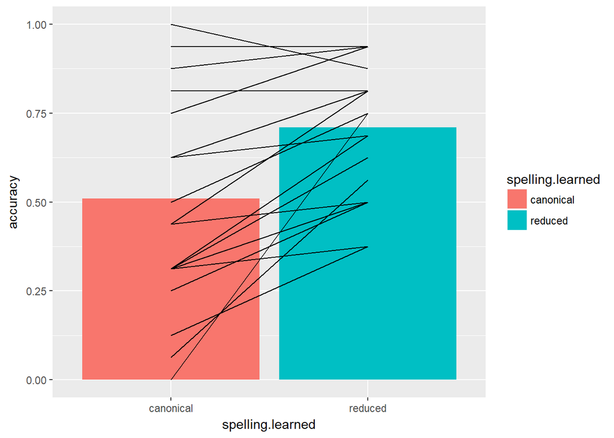

```r
CR_sess3.bySubject <- aggregate(accuracy~ID+spelling.learned,exp2_session3_CR, FUN="mean")


ggplot(CR_sess3.means, aes(spelling.learned, accuracy))+
  geom_bar(stat="identity", position="dodge", aes(fill=spelling.learned))+
  geom_line(data=CR_sess3.bySubject, aes(group=ID, x=spelling.learned, y=accuracy))
```

#### Analysis: Effect of Orthography within the Canonical_Reduced group (Session 3)

Model with fixed effect

```r
CR.sess3.mod1<-glmer(accuracy ~ spelling.learned + (1|ID) + (1|item), exp2_session3_CR, family="binomial")

summary(CR.sess3.mod1)
```

```
## Generalized linear mixed model fit by maximum likelihood (Laplace
##   Approximation) [glmerMod]
##  Family: binomial  ( logit )
## Formula: accuracy ~ spelling.learned + (1 | ID) + (1 | item)
##    Data: exp2_session3_CR
##
##      AIC      BIC   logLik deviance df.resid
##      709      727     -350      701      636
##
## Scaled residuals:
##    Min     1Q Median     3Q    Max
## -4.982 -0.630  0.282  0.596  2.369
##
## Random effects:
##  Groups Name        Variance Std.Dev.
##  item   (Intercept) 0.765    0.875
##  ID     (Intercept) 1.709    1.307
## Number of obs: 640, groups:  item, 32; ID, 20
##
## Fixed effects:
##                         Estimate Std. Error z value Pr(>|z|)
## (Intercept)               0.0834     0.3892    0.21  0.83027
## spelling.learnedreduced   1.2458     0.3708    3.36  0.00078 ***
## ---
## Signif. codes:  0 '***' 0.001 '**' 0.01 '*' 0.05 '.' 0.1 ' ' 1
##
## Correlation of Fixed Effects:
##             (Intr)
## spllng.lrnd -0.452
```

There is an effect of spelling within the Canonical_Reduced group.

### Generalization to the items that did not receive a spelling? (Session 3)

Data:

```r
exp2_session3_CNRN <-exp2_session3_canonical[exp2_session3_canonical$group %in% c("Canonical_None", "Reduced_None"),]
exp2_session3_CNRN<-exp2_session3_CNRN[exp2_session3_CNRN$spelling.learned == "none",]
```

#### Means:

```
##            group accuracy
## 1 Canonical_None     0.61
## 2   Reduced_None     0.72
```

#### Plot:

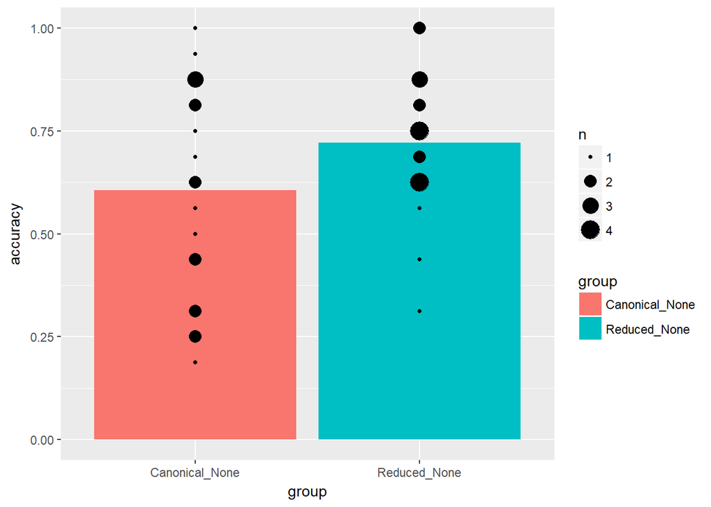

#### Analysis: Difference between the Canonical_None and Reduced_None groups for the no spelling items? (Session 3)

Model with fixed effect:

```
## Generalized linear mixed model fit by maximum likelihood (Laplace
##   Approximation) [glmerMod]
##  Family: binomial  ( logit )
## Formula: accuracy ~ group + (1 | ID) + (1 | item)
##    Data: exp2_session3_CNRN
##
##      AIC      BIC   logLik deviance df.resid
##      642      660     -317      634      636
##
## Scaled residuals:
##    Min     1Q Median     3Q    Max
## -7.501 -0.506  0.221  0.446  3.369
##
## Random effects:
##  Groups Name        Variance Std.Dev.
##  ID     (Intercept) 2.15     1.47
##  item   (Intercept) 2.58     1.61
## Number of obs: 640, groups:  ID, 40; item, 32
##
## Fixed effects:
##                   Estimate Std. Error z value Pr(>|z|)
## (Intercept)          0.725      0.540    1.34     0.18
## groupReduced_None    1.038      0.774    1.34     0.18
##
## Correlation of Fixed Effects:
##             (Intr)
## gropRdcd_Nn -0.693
```

THere were no generalization effects in Session 3.

### Interaction between learning context and effect of orthography?

Data:

```r
exp2_session3_interaction<-exp2_session3_canonical
exp2_session3_interaction <- exp2_session3_interaction[exp2_session3_interaction$spelling.learned %in% c("canonical", "reduced"),]

##creating the new variable:
exp2_session3_interaction$learning<-exp2_session3_interaction$group
exp2_session3_interaction$learning<-revalue(exp2_session3_interaction$learning, c("Canonical_None"="simple",
                                     "Reduced_None"="simple",
                                     "Canonical_Reduced" = "complex"))
```

#### Means:

```
##   spelling.learned learning accuracy
## 1        canonical   simple     0.49
## 2          reduced   simple     0.82
## 3        canonical  complex     0.51
## 4          reduced  complex     0.71
```

#### Plot:

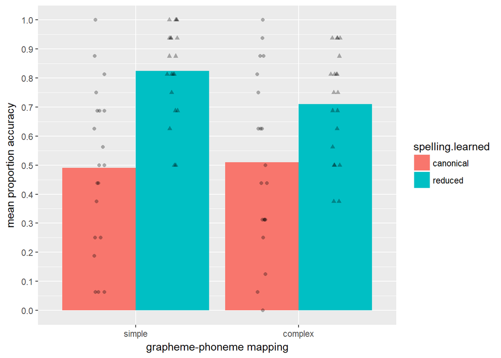

#### Analysis: Interaction between learning context and orthography effect?

Main model:

```r
sess3_interaction.mod1 <-glmer(accuracy ~ learning/spelling.learned + (1|ID)+(1|item), exp2_session3_interaction, family="binomial")
summary(sess3_interaction.mod1)
```

```
## Generalized linear mixed model fit by maximum likelihood (Laplace
##   Approximation) [glmerMod]
##  Family: binomial  ( logit )
## Formula: accuracy ~ learning/spelling.learned + (1 | ID) + (1 | item)
##    Data: exp2_session3_interaction
##
##      AIC      BIC   logLik deviance df.resid
##     1312     1343     -650     1300     1273
##
## Scaled residuals:
##    Min     1Q Median     3Q    Max
## -5.929 -0.564  0.236  0.547  3.356
##
## Random effects:
##  Groups Name        Variance Std.Dev.
##  ID     (Intercept) 1.906    1.381
##  item   (Intercept) 0.952    0.976
## Number of obs: 1279, groups:  ID, 60; item, 32
##
## Fixed effects:
##                                         Estimate Std. Error z value
## (Intercept)                              -0.0697     0.4177   -0.17
## learningcomplex                           0.1545     0.4784    0.32
## learningsimple:spelling.learnedreduced    2.3878     0.6099    3.92
## learningcomplex:spelling.learnedreduced   1.2925     0.4017    3.22
##                                         Pr(>|z|)
## (Intercept)                               0.8674
## learningcomplex                           0.7468
## learningsimple:spelling.learnedreduced     9e-05 ***
## learningcomplex:spelling.learnedreduced   0.0013 **
## ---
## Signif. codes:  0 '***' 0.001 '**' 0.01 '*' 0.05 '.' 0.1 ' ' 1
##
## Correlation of Fixed Effects:
##             (Intr) lrnngc lrnngs:.
## lernngcmplx -0.575
## lrnngsmpl:. -0.685  0.395
## lrnngcmpl:. -0.355 -0.092  0.498
```

Base model:

```r
sess3_interaction.mod0 <-glmer(accuracy ~ learning+spelling.learned + (1|ID)+(1|item), exp2_session3_interaction, family="binomial")
summary(sess3_interaction.mod0)
```

```
## Generalized linear mixed model fit by maximum likelihood (Laplace
##   Approximation) [glmerMod]
##  Family: binomial  ( logit )
## Formula: accuracy ~ learning + spelling.learned + (1 | ID) + (1 | item)
##    Data: exp2_session3_interaction
##
##      AIC      BIC   logLik deviance df.resid
##     1314     1340     -652     1304     1274
##
## Scaled residuals:
##    Min     1Q Median     3Q    Max
## -6.245 -0.569  0.237  0.536  3.265
##
## Random effects:
##  Groups Name        Variance Std.Dev.
##  ID     (Intercept) 1.997    1.413
##  item   (Intercept) 0.943    0.971
## Number of obs: 1279, groups:  ID, 60; item, 32
##
## Fixed effects:
##                         Estimate Std. Error z value Pr(>|z|)
## (Intercept)                0.371      0.362    1.03  0.30499
## learningcomplex           -0.353      0.417   -0.85  0.39777
## spelling.learnedreduced    1.448      0.394    3.67  0.00024 ***
## ---
## Signif. codes:  0 '***' 0.001 '**' 0.01 '*' 0.05 '.' 0.1 ' ' 1
##
## Correlation of Fixed Effects:
##             (Intr) lrnngc
## lernngcmplx -0.425
## spllng.lrnd -0.531  0.007
```

Comparing the two:

```r
anova(sess3_interaction.mod0, sess3_interaction.mod1)
```

```
## Data: exp2_session3_interaction
## Models:
## sess3_interaction.mod0: accuracy ~ learning + spelling.learned + (1 | ID) + (1 | item)
## sess3_interaction.mod1: accuracy ~ learning/spelling.learned + (1 | ID) + (1 | item)
##                        Df  AIC  BIC logLik deviance Chisq Chi Df
## sess3_interaction.mod0  5 1314 1340   -652     1304
## sess3_interaction.mod1  6 1312 1343   -650     1300  4.09      1
##                        Pr(>Chisq)
## sess3_interaction.mod0
## sess3_interaction.mod1      0.043 *
## ---
## Signif. codes:  0 '***' 0.001 '**' 0.01 '*' 0.05 '.' 0.1 ' ' 1
```